# 8-2疫情数据爬取及词云图地图 - week14

## 一.肺炎疫情可视化分析

```
  1. 在谷歌浏览器或其它浏览器输入“实时更新 肺炎疫情”，将这些数据抓取下来
   2.先在代码块查看广东数据，查看代码找导趋势运行network,找到list 复制链接“https://api.inews.qq.com/newsqa/v1/query/pubished/daily/list?province=%E5%B9%BF%E4%B8%9C&”可以看到数据变化。只要修改province=其它地区。所有数据都在这里。
```

```python
#网页内容抓取
import requests
import xlwt
import json
import re
import os

province=input("请输入查询的省份：")
url="https://api.inews.qq.com/newsqa/v1/query/pubished/daily/list?province="
headers={'User-Agent': 'Mozilla/5.0 (Windows NT 10.0; Win64; x64) AppleWebKit/537.36 (KHTML, like Gecko) Chrome/88.0.4324.190 Safari/537.36'}
#response=requests.get(url)
data={"province":province}
#发出请求
page_text=requests.post(url=url,headers=headers,data=data).json()
#打印json文件
fileName=province+'.json'
fp=open(fileName,'w',encoding='utf-8')
json.dump(page_text,fp=fp,ensure_ascii=False)
```

2.我们可以在百度中进行json代码解析，发现数据变化，很多数据都在data键里，注释上面的最后三行代码。

```python
#网页内容抓取
#1.导入包
import requests
import xlwt #操作excel
import json
import re
#2.定义一个查询
province=input("请输入查询的省份：")
#3.定位新冠肺炎国内的url,找到json文件。
url="https://api.inews.qq.com/newsqa/v1/query/pubished/daily/list?province="
#4.伪装浏览器
headers={'User-Agent': 'Mozilla/5.0 (Windows NT 10.0; Win64; x64) AppleWebKit/537.36 (KHTML, like Gecko) Chrome/88.0.4324.190 Safari/537.36'}
#response=requests.get(url)
#5.查询字段
data={"province":province}
#6.发出请求
page_text=requests.post(url=url,headers=headers,data=data).json()
#7.打印json文件
#fileName=province+'.json'
#fp=open(fileName,'w',encoding='utf-8')
#json.dump(page_text,fp=fp,ensure_ascii=False)
#8.提取json文件中的data键
data=page_text['data']
#9.查看提取data键内容
data
#10.查看总提取的日期天数
dada_num=len(data) #计算总共统计了多少天
book=xlwt.Workbook(encoding='utf-8')
sheet=book.add_sheet('疫情数据',cell_overwrite_ok=True)
#列名
col_name=['省份','日期','累计确诊','累计死亡','累计治愈','境外输入']
#11，先将列名写入到表中
for i in range(0,6):
    sheet.write(0,i,col_name[i])
#12.将提取的具体数据写入excel表
for i in range(dada_num):
    sheet.write(i+1,0,province)
    sheet.write(i+1,1,data[i]['date'])
    sheet.write(i+1,2,data[i]['confirm'])
    sheet.write(i+1,3,data[i]['dead'])
    sheet.write(i+1,4,data[i]['heal'])

    #提取境外输入的病例，使用正则表达式
    ex='确诊病例(.*?)例 | 新增(.*?)例'
    #配置表达式,使用贪婪模式
    match=re.findall(ex,data[i]['description'])

    if len(match)==0:
        sheet.write(i+1,5,0)
    else:
        sheet.write(i+1,5,int(match[0]))
    print("%s数据爬取结束"%(data[i]['date']))
#13.将爬取到的文件存入到excel表中
book.save(province+'疫情数据'+'.xls')
print("数据爬取结束。。。。。")
```

```
请输入查询的省份：江苏
01.22数据爬取结束
01.23数据爬取结束
01.24数据爬取结束
01.25数据爬取结束
01.26数据爬取结束
01.27数据爬取结束
01.28数据爬取结束
01.29数据爬取结束
01.30数据爬取结束
01.31数据爬取结束
02.01数据爬取结束
02.02数据爬取结束
02.03数据爬取结束
02.04数据爬取结束
02.05数据爬取结束
02.06数据爬取结束
02.07数据爬取结束
02.08数据爬取结束
02.09数据爬取结束
02.10数据爬取结束
02.11数据爬取结束
02.12数据爬取结束
02.13数据爬取结束
02.14数据爬取结束
02.15数据爬取结束
02.16数据爬取结束
02.17数据爬取结束
02.18数据爬取结束
02.19数据爬取结束
02.20数据爬取结束
02.21数据爬取结束
02.22数据爬取结束
02.23数据爬取结束
02.24数据爬取结束
02.25数据爬取结束
02.26数据爬取结束
02.27数据爬取结束
02.28数据爬取结束
02.29数据爬取结束
```

[output cut: 448 more lines]

```
05.23数据爬取结束
05.24数据爬取结束
05.25数据爬取结束
05.26数据爬取结束
05.27数据爬取结束
05.28数据爬取结束
05.29数据爬取结束
05.30数据爬取结束
05.31数据爬取结束
06.01数据爬取结束
06.02数据爬取结束
06.03数据爬取结束
06.04数据爬取结束
06.05数据爬取结束
数据爬取结束。。。。。
```

## 二，全国疫情数据的爬取

1 .定义全省列表：# 全国省份 province_name = ['北京', '上海', '江苏', '广东', '浙江', '陕西', '山西','河北','河南','湖北','湖南','安徽','山东','重庆','四川','辽宁', '吉林','黑龙江','天津','福建','云南','贵州','青海','海南','西藏','广西','宁夏','甘肃','新疆','内蒙古','江西'] 2.使用for 循环遍历列表。

```python
import requests
import xlwt
import json
import re
import os
# 全国省份
province_name = ['北京', '上海', '江苏', '广东', '浙江', '陕西', '山西','河北','河南','湖北','湖南','安徽','山东','重庆','四川','辽宁',
                     '吉林','黑龙江','天津','福建','云南','贵州','青海','海南','西藏','广西','宁夏','甘肃','新疆','内蒙古','江西']

for item in range(len(province_name)):

    province = province_name[item]

    url = 'https://api.inews.qq.com/newsqa/v1/query/pubished/daily/list?province='
    headers = {
            'User-Agent': 'Mozilla/5.0 (Windows NT 10.0; Win64; x64) AppleWebKit/537.36 (KHTML, like Gecko) Chrome/84.0.4147.105 Safari/537.36'
        }
    data = {
            'province': province
        }
    page_text = requests.post(url=url, data=data, headers=headers).json()
        # fileName = province+'.json'
        # fp = open(fileName,'w',encoding='utf-8')
        # json.dump(page_text,fp=fp,ensure_ascii=False)
    data = page_text['data']
        # print(data)
    date_num = len(data)  # 计算总共的天数

    book = xlwt.Workbook(encoding='utf-8')
    sheet = book.add_sheet('疫情数据', cell_overwrite_ok=True)
    col_name = ['省份', '日期', '累计确诊', '累计死亡', '累计治愈', '境外输入']
    for i in range(0, 6):
        sheet.write(0, i, col_name[i])

    for i in range(date_num):
        sheet.write(i + 1, 0, province)
        y = data[i]['date'].split('.')[0]
        m = data[i]['date'].split('.')[1]
        sheet.write(i + 1, 1, y+'月'+m+'日')
        sheet.write(i + 1, 2, data[i]['confirm'])
        sheet.write(i + 1, 3, data[i]['dead'])
        sheet.write(i + 1, 4, data[i]['heal'])


            # 提取境外输入病例
        ex = '确诊病例(.*?)例 | 新增(.*?)例'

        match = re.findall(ex, data[i]['description'])

        if len(match) == 0:
            sheet.write(i + 1, 5, 0)
        else:
            sheet.write(i + 1, 5, int(match[0]))

    print('%s   爬取结束'%province)
    #如果没有全国各地疫情数据文件夹则创建
    if not os.path.exists('./全国各地疫情数据'):
        os.mkdir('./全国各地疫情数据')

    book.save('./全国各地疫情数据/'+province + '疫情数据' + '.xls')

print('爬取结束----')
```

可以使用finebi软件建模可视化非常快不用设置太多代码，数据建模大赛基本用这个（我们软件专业还是pyecharts）。

## 数据提取

```python
import pandas as pd
import xlwt
import numpy as np
from datetime import datetime
date = input('请输入想要提取的日期（格式如08月01日）:')


book = xlwt.Workbook(encoding='utf-8')
sheet = book.add_sheet('同一日期提取',cell_overwrite_ok=True)
col_name = ['省份','累计确诊', '累计死亡', '累计治愈', '境外输入']
for i in range(0,5):
    sheet.write(0,i,col_name[i])

    province_name = ['北京', '上海', '江苏', '广东', '浙江', '陕西', '山西', '河北', '河南', '湖北', '湖南', '安徽', '山东', '重庆', '四川', '辽宁',
                     '吉林', '黑龙江', '天津', '福建', '云南', '贵州', '青海', '海南', '西藏', '广西', '宁夏', '甘肃', '新疆', '内蒙古', '江西']

    for i in range(len(province_name)):
        province = province_name[i]
        # print(province)
        filename = './全国各地疫情数据/'+province+'疫情数据.xls'
        data  = pd.read_excel(filename)
        deal_num = data['日期']
        for j in range(len(deal_num)):
            if deal_num[j] == date:
                sheet.write(i+1,0,province)
                sheet.write(i+1,1,int(data['累计确诊'][j]))
                sheet.write(i+1,2,int(data['累计死亡'][j]))
                sheet.write(i+1,3,int(data['累计治愈'][j]))
                sheet.write(i+1,4,int(data['境外输入'][j]))
        print('%s提取完毕'%province)

    book.save('全国各地'+date+'提取结果.xlsx')
print('处理完毕......')
```

```
请输入想要提取的日期（格式如08月01日）:06月08
北京提取完毕
上海提取完毕
江苏提取完毕
广东提取完毕
浙江提取完毕
陕西提取完毕
山西提取完毕
河北提取完毕
河南提取完毕
湖北提取完毕
湖南提取完毕
安徽提取完毕
山东提取完毕
重庆提取完毕
四川提取完毕
辽宁提取完毕
吉林提取完毕
黑龙江提取完毕
天津提取完毕
福建提取完毕
云南提取完毕
贵州提取完毕
青海提取完毕
海南提取完毕
西藏提取完毕
广西提取完毕
宁夏提取完毕
甘肃提取完毕
新疆提取完毕
内蒙古提取完毕
江西提取完毕
北京提取完毕
上海提取完毕
江苏提取完毕
广东提取完毕
浙江提取完毕
陕西提取完毕
山西提取完毕
河北提取完毕
```

[output cut: 102 more lines]

```
黑龙江提取完毕
天津提取完毕
福建提取完毕
云南提取完毕
贵州提取完毕
青海提取完毕
海南提取完毕
西藏提取完毕
广西提取完毕
宁夏提取完毕
甘肃提取完毕
新疆提取完毕
内蒙古提取完毕
江西提取完毕
处理完毕......
```

### 制作词云图，将各省的省份与他相关联的累计确诊人数进行制作

```
1.导入包
2.读取数据
3.数据处理
```

```python
import openpyxl
from wordcloud import  WordCloud
```

```python
# 1.读取数据
wb = openpyxl.load_workbook('data.xlsx')
# 2.获取工作表
ws = wb['国内疫情']
#5.我们创建一个字典将他们关联，将省份和确诊人数关联
frequency_in = {}
frequency={}
for row in ws.values:
    #print(row)#3.我们看到所需要的数据以元组形式全打印出来啦
    #4.我们去掉表头第一列标题，通过一个if语句
    if row[0]=='省份':
        pass
    else:
        frequency[row[0]]=row[1] #将省份和确诊人数关联
#6.打印查看是否写入字典
#print(frequency) #查看到了后我们删除打印的语句

#7.制作词云，首先实列化WordCloud类并赋值给一个变量
```

### 二、制作词云 ，字体越大表示疫情越高，字体越小表示疫情底

```
1.删除打印的字典
2.首先实列化WordCloud类并赋值给一个变量
3.由于词云用的是中文所以引入字体（c盘windows,fonts文件夹，选择你喜欢的字体，选择隶书）复制文件名和路径。并指定背景颜色,生成图片的高度和宽度。
1）指定字体：font_path="C:/Windows/Fonts/SIMLI.TTF"
2）指定背景颜色： background_color="white"
3）指定图片的高和宽：width=1920, height=1080
4. 根据确诊病例的数目生成词云,调用wordcloud的generate_from_frequencies方法

wordcloud.generate_from_frequencies(frequency)#将字典数据生成词云
5.保存词云
wordcloud.to_file("疫情词云.png")
6.显示词云图
image=wordcloud.to_image()
image.show()
```

```python
# 1.读取数据
wb = openpyxl.load_workbook('data.xlsx')
# 2.获取工作表
ws = wb['国内疫情']
#5.我们创建一个字典将他们关联，将省份和确诊人数关联
frequency_in = {}
frequency={}
for row in ws.values:
    #print(row)#3.我们看到所需要的数据以元组形式全打印出来啦
    #4.我们去掉表头第一列标题，通过一个if语句
    if row[0]=='省份':
        pass
    else:
        frequency[row[0]]=float(row[1]) #将省份和确诊人数关联,可以不转换数据类型
#6.打印查看是否写入字典


#7.制作词云，首先实列化WordCloud类并赋值给一个变量,词云是中文导入字体（c盘windows,fonts文件夹）
wordcloud=WordCloud(font_path='C:\Windows\Fonts\SIMLI.TTF',
                  background_color='white',width=1920, height=1080 )
#8. # 根据确诊病例的数目生成词云，调用wordcloud的generate_from_frequencies方法
wordcloud.generate_from_frequencies(frequency)#将字典数据生成词云
#9.保存词云
wordcloud.to_file("疫情词云.png")
#10.显示词云图
image=wordcloud.to_image()
image.show()
```

### 1.使用遮罩显示图云

1.先找一个图片 2.导入包 3.# 这里可以事先准备一张图片，可以用作背景

```
# background_image = np.array(Image.open('pic.jpg'))
```

4.把词云对象的背景颜色改为 mask=background_image

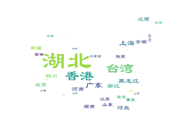

```python
import matplotlib.pyplot as plt   # 绘制图像的模块
import numpy as np
from PIL import Image

# 1.读取数据
wb=openpyxl.load_workbook('data.xlsx')
# 2.获取工作表
ws = wb['国内疫情']
#5.我们创建一个字典将他们关联，将省份和确诊人数关联
frequency_in = {}
frequency={}
for row in ws.values:
    #print(row)#3.我们看到所需要的数据以元组形式全打印出来啦
    #4.我们去掉表头第一列标题，通过一个if语句
    if row[0]=='省份':
        pass
    else:
        frequency[row[0]]=float(row[1]) #将省份和确诊人数关联,可以不转换数据类型
#6.打印查看是否写入字典


#7.制作词云，首先实列化WordCloud类并赋值给一个变量,词云是中文导入字体（c盘windows,fonts文件夹）
# 这里可以事先准备一张图片，可以用作背景
background_image = np.array(Image.open('china3.jpg'))
wordcloud=WordCloud(font_path='C:\Windows\Fonts\SIMLI.TTF',
                    background_color='white',
                   mask=background_image
                    )
#8. # 根据确诊病例的数目生成词云，调用wordcloud的generate_from_frequencies方法
wordcloud.generate_from_frequencies(frequency)#将字典数据生成词云
#9.保存词云
wordcloud.to_file("疫情词云.png")
#10.显示词云图
# 展示图片
plt.imshow(wordcloud, interpolation="bilinear")
plt.axis("off")
plt.show()
```

### 附件2.国内外疫情词云图完整代码（以下是另外一种方式进行，先爬取文文本文档再json转换）

```python
import openpyxl
from wordcloud import WordCloud
from pyecharts import options as opts
from pyecharts.charts import WordCloud

# 与即时显示图片相关的模块
'''
import matplotlib.pyplot as plt   # 绘制图像的模块
import numpy as np
from PIL import Image
'''

# 读取数据
wb = openpyxl.load_workbook('data.xlsx')
sheet_names = wb.sheetnames

frequency_out = {}
for each in sheet_names:
    if '洲' in each:
        ws = wb[each]
        for row in ws.values:
            if row[1] == "累计确诊":
                pass
            else:
                frequency_out[row[0]] = float(row[1])
    else:
        pass


# 以省份的确诊病例总数代表其出现的频率
frequency_in = {}
ws = wb['国内疫情']
for row in ws.values:
    if row[1] == "累计确诊":
        pass
    else:
        frequency_in[row[0]] = float(row[1])

def generate_pic(frequency,name):
    # 这里可以事先准备一张图片，可以用作背景
    # background_image = np.array(Image.open('pic.jpg'))
    wordcloud = WordCloud(font_path="C:/Windows/Fonts/SIMLI.TTF",
                          background_color = "red",
                          # mask=background_image,
                          width=1920, height=1080
                          )
    # 按照确诊病例数目生成词云
    wordcloud.generate_from_frequencies(frequency)
    wordcloud.to_file('%s.png'%name)

    # 展示图片
    # plt.imshow(wordcloud, interpolation="bilinear")
    # plt.axis("off")
    # plt.show()

# 调用函数
generate_pic(frequency_in,'国内疫情')
generate_pic(frequency_out,'国外疫情')
```

### 3.疫情地图

1.导入包（pip install pyecharts） 2.打开爬取数据（以上面爬取数据是在Excel表格里）

```python
from pyecharts.charts import Pie, Map, Bar, Line, Grid, Page,Funnel #插件可以绘制很酷炫的图形
from pyecharts import options as opts
import openpyxl

# 1.读取数据
wb = openpyxl.load_workbook('data.xlsx')
# 2.获取工作表
ws = wb['国内疫情']
#5.我们创建一个字典将他们关联，将省份和确诊人数关联
frequency_in = {}
frequency={}
for row in ws.values:
    #print(row)#3.我们看到所需要的数据以元组形式全打印出来啦
    #4.我们去掉表头第一列标题，通过一个if语句
    if row[0]=='省份':
        pass
    else:
        frequency[row[0]]=float(row[1]) #将省份和确诊人数关联,可以不转换数据类型
#6.打印查看是否写入字典
print(frequency)
provice = list(frequency.keys())
num = list(frequency.values())
```

```
{'西藏': 1.0, '澳门': 51.0, '青海': 18.0, '台湾': 10956.0, '香港': 11851.0, '贵州': 147.0, '吉林': 573.0, '新疆': 980.0, '宁夏': 76.0, '内蒙古': 388.0, '甘肃': 194.0, '天津': 394.0, '山西': 253.0, '辽宁': 425.0, '黑龙江': 1612.0, '海南': 188.0, '河北': 1317.0, '陕西': 618.0, '云南': 358.0, '广西': 275.0, '福建': 629.0, '上海': 2124.0, '北京': 106…
```

```python
### 3.画图

pieces = [{"max": 999999, "min": 1001, "label": ">10000", "color": "#8A0808"},
                {"max": 9999, "min": 1000, "label": "1000-9999", "color": "#B40404"},
                  {"max": 999, "min": 100, "label": "100-999", "color": "#DF0101"},
                  {"max": 99, "min": 10, "label": "10-99", "color": "#F78181"},
                  {"max": 9, "min": 1, "label": "1-9", "color": "#F5A9A9"},
                  {"max": 0, "min": 0, "label": "0", "color": "#FFFFFF"},
                  ]

chinaMap =Map(init_opts=opts.InitOpts(width = '1000px', height='880px'))
chinaMap.add("累计确诊人数", [list(z) for z in zip(provice,num)], "china", is_map_symbol_show=False)
chinaMap.set_global_opts(
                title_opts=opts.TitleOpts(title="中国疫情地图分布", subtitle='截止中国疫情分布情况', pos_left="center", pos_top="10px"),
                legend_opts=opts.LegendOpts(is_show=False),
                visualmap_opts=opts.VisualMapOpts(max_=200, is_piecewise=True,
                                                  pieces=pieces,
                                                  ))


chinaMap.render("中国疫情地图.html")
chinaMap.render_notebook()
```

### 案例另一种方法抓取全球疫情数据（可以自己参考）

以下是文件源码

```python
import requests
from lxml import etree
import json
import re
import openpyxl
```

```python
#1.抓取数据以html.txt 文件类型写入(url = "https://voice.baidu.com/act/newpneumonia/newpneumonia/")
# 目标url
url = "https://voice.baidu.com/act/newpneumonia/newpneumonia/"

        # 伪装请求头
headers = {
            'User-Agent': 'Mozilla/5.0 (Windows NT 10.0; Win64; x64) AppleWebKit/537.36 (KHTML, like Gecko) '
                          'Chrome/80.0.3987.149 Safari/537.36 '
        }

        # 发出get请求
response = requests.get(url,headers=headers)

        # 将请求的结果写入文件,便于分析
with open('html.txt', 'w') as file:

    file.write(response.text)
```

```python
#2.打开文件获取疫情数据日期
with open('html.txt','r') as file:

    text = file.read()
        # 获取更新时间
    time_in = re.findall('"mapLastUpdatedTime":"(.*?)"',text)[0]
    time_out = re.findall('"foreignLastUpdatedTime":"(.*?)"',text)[0]
    print('国内疫情更新时间为 '+time_in)
    print('国外疫情更新时间为 '+time_out)
```

```python
#3.打开文件进行数据转换，即转为json,excel,包含国内外数据
 with open('html.txt','r') as file:
            text = file.read()
        # 生成HTML对象
        html = etree.HTML(text)
        # 解析数据
        result = html.xpath('//script[@type="application/json"]/text()')
        # print(type(result))
        result = result[0]
        # print(type(result))
        result = json.loads(result)
        # print(type(result))
        result = json.dumps(result['component'][0]['caseList'])
        # print(result)
        # print(type(result))
        with open('data.json','w') as file:
            file.write(result)
            print('数据已写入json文件...')

        response = requests.get("https://voice.baidu.com/act/newpneumonia/newpneumonia/")
        # 将请求的结果写入文件,便于分析
        with open('html.txt', 'w') as file:
            file.write(response.text)

        # 获取时间
        time_in = re.findall('"mapLastUpdatedTime":"(.*?)"', response.text)[0]
        time_out = re.findall('"foreignLastUpdatedTime":"(.*?)"', response.text)[0]
        print(time_in)
        print(time_out)

        # 生成HTML对象
        html = etree.HTML(response.text)
        # 解析数据
        result = html.xpath('//script[@type="application/json"]/text()')
        print(type(result))
        result = result[0]
        print(type(result))
        result = json.loads(result)
        print(type(result))
        # 以每个省的数据为一个字典
        data_in = result['component'][0]['caseList']
        for each in data_in:
            print(each)
            print("\n" + '*' * 20)

        data_out = result['component'][0]['globalList']
        for each in data_out:
            print(each)
            print("\n" + '*' * 20)

        '''
        area --> 大多为省份
        city --> 城市
        confirmed --> 累计
        died --> 死亡
        crued --> 治愈
        relativeTime -->
        confirmedRelative --> 累计的增量
        curedRelative --> 治愈的增量
        curConfirm --> 现有确诊
        curConfirmRelative --> 现有确诊的增量
        diedRelative --> 死亡的增量
        '''

        # 规律----遍历列表的每一项,可以发现,每一项(type:字典)均代表一个省份等区域,这个字典的前11项是该省份的疫情数据,
        # 当key = 'subList'时,其结果为只有一项的列表,提取出列表的第一项,得到一系列的字典,字典中包含该城市的疫情数据.

        # 将得到的数据写入excel文件
        # 创建一个工作簿
        wb = openpyxl.Workbook()
        # 创建工作表,每一个工作表代表一个area
        ws_in = wb.active
        ws_in.title = "国内疫情"
        ws_in.append(['省份', '累计确诊', '死亡', '治愈', '现有确诊', '累计确诊增量', '死亡增量', '治愈增量', '现有确诊增量'])
        for each in data_in:
            temp_list = [each['area'], each['confirmed'], each['died'], each['crued'], each['curConfirm'],
                         each['confirmedRelative'], each['diedRelative'], each['curedRelative'],
                         each['curConfirmRelative']]
            for i in range(len(temp_list)):
                if temp_list[i] == '':
                    temp_list[i] = '0'
            ws_in.append(temp_list)

        # 获取国外疫情数据
        for each in data_out:
            print(each)
            print("\n" + '*' * 20)
            sheet_title = each['area']
            # 创建一个新的工作表
            ws_out = wb.create_sheet(sheet_title)
            ws_out.append(['国家', '累计确诊', '死亡', '治愈', '现有确诊', '累计确诊增量'])
            for country in each['subList']:
                list_temp = [country['country'], country['confirmed'], country['died'], country['crued'],
                             country['curConfirm'], country['confirmedRelative']]
                for i in range(len(list_temp)):
                    if list_temp[i] == '':
                        list_temp[i] = '0'
                ws_out.append(list_temp)

            # 保存excel文件
            wb.save('./data.xlsx')
```

```python
import requests
from lxml import etree
import json
import re
import openpyxl


class Get_data():
    def get_data(self):
        # 目标url
        url = "https://voice.baidu.com/act/newpneumonia/newpneumonia/"

        # 伪装请求头
        headers = {
            'User-Agent': 'Mozilla/5.0 (Windows NT 10.0; Win64; x64) AppleWebKit/537.36 (KHTML, like Gecko) '
                          'Chrome/80.0.3987.149 Safari/537.36 '
        }

        # 发出get请求
        response = requests.get(url,headers=headers)

        # 将请求的结果写入文件,便于分析
        with open('html.txt', 'w') as file:
            file.write(response.text)

    def get_time(self):
        with open('html.txt','r') as file:
            text = file.read()
        # 获取更新时间
        time_in = re.findall('"mapLastUpdatedTime":"(.*?)"',text)[0]
        time_out = re.findall('"foreignLastUpdatedTime":"(.*?)"',text)[0]
        print('国内疫情更新时间为 '+time_in)
        print('国外疫情更新时间为 '+time_out)
        return time_in,time_out

    def parse_data(self):
        with open('html.txt','r') as file:
            text = file.read()
        # 生成HTML对象
        html = etree.HTML(text)
        # 解析数据
        result = html.xpath('//script[@type="application/json"]/text()')
        # print(type(result))
        result = result[0]
        # print(type(result))
        result = json.loads(result)
        # print(type(result))
        result = json.dumps(result['component'][0]['caseList'])
        # print(result)
        # print(type(result))
        with open('data.json','w') as file:
            file.write(result)
            print('数据已写入json文件...')

        response = requests.get("https://voice.baidu.com/act/newpneumonia/newpneumonia/")
        # 将请求的结果写入文件,便于分析
        with open('html.txt', 'w') as file:
            file.write(response.text)

        # 获取时间
        time_in = re.findall('"mapLastUpdatedTime":"(.*?)"', response.text)[0]
        time_out = re.findall('"foreignLastUpdatedTime":"(.*?)"', response.text)[0]
        print(time_in)
        print(time_out)

        # 生成HTML对象
        html = etree.HTML(response.text)
        # 解析数据
        result = html.xpath('//script[@type="application/json"]/text()')
        print(type(result))
        result = result[0]
        print(type(result))
        result = json.loads(result)
        print(type(result))
        # 以每个省的数据为一个字典
        data_in = result['component'][0]['caseList']
        for each in data_in:
            print(each)
            print("\n" + '*' * 20)

        data_out = result['component'][0]['globalList']
        for each in data_out:
            print(each)
            print("\n" + '*' * 20)

        '''
        area --> 大多为省份
        city --> 城市
        confirmed --> 累计
        died --> 死亡
        crued --> 治愈
        relativeTime -->
        confirmedRelative --> 累计的增量
        curedRelative --> 治愈的增量
        curConfirm --> 现有确诊
        curConfirmRelative --> 现有确诊的增量
        diedRelative --> 死亡的增量
        '''

        # 规律----遍历列表的每一项,可以发现,每一项(type:字典)均代表一个省份等区域,这个字典的前11项是该省份的疫情数据,
        # 当key = 'subList'时,其结果为只有一项的列表,提取出列表的第一项,得到一系列的字典,字典中包含该城市的疫情数据.

        # 将得到的数据写入excel文件
        # 创建一个工作簿
        wb = openpyxl.Workbook()
        # 创建工作表,每一个工作表代表一个area
        ws_in = wb.active
        ws_in.title = "国内疫情"
        ws_in.append(['省份', '累计确诊', '死亡', '治愈', '现有确诊', '累计确诊增量', '死亡增量', '治愈增量', '现有确诊增量'])
        for each in data_in:
            temp_list = [each['area'], each['confirmed'], each['died'], each['crued'], each['curConfirm'],
                         each['confirmedRelative'], each['diedRelative'], each['curedRelative'],
                         each['curConfirmRelative']]
            for i in range(len(temp_list)):
                if temp_list[i] == '':
                    temp_list[i] = '0'
            ws_in.append(temp_list)

        # 获取国外疫情数据
        for each in data_out:
            print(each)
            print("\n" + '*' * 20)
            sheet_title = each['area']
            # 创建一个新的工作表
            ws_out = wb.create_sheet(sheet_title)
            ws_out.append(['国家', '累计确诊', '死亡', '治愈', '现有确诊', '累计确诊增量'])
            for country in each['subList']:
                list_temp = [country['country'], country['confirmed'], country['died'], country['crued'],
                             country['curConfirm'], country['confirmedRelative']]
                for i in range(len(list_temp)):
                    if list_temp[i] == '':
                        list_temp[i] = '0'
                ws_out.append(list_temp)

            # 保存excel文件
            wb.save('./data.xlsx')
```